# ML_Stock_Price_Prediction

## ML Based Stock Price Prediction Using Python

This is a simple stock prediction algorithm using Scikit-Learn , it is using Pandas Data reader to get the data from Yahoo It is currently using a linear regression model

```python
import numpy as np
import pandas as pd
import datetime
import math
import pandas_datareader.data as web
import matplotlib.pyplot as plt

from sklearn import preprocessing, svm
from sklearn.linear_model import LinearRegression
from sklearn.model_selection  import cross_validate
from sklearn.model_selection import train_test_split
from matplotlib import style
```

After importing the neccessary variables the next step is to define the time period for the data to be used , this is crucial for forecasting the more history the better prediction . I have chosen Apple for as the sticker

```python
begin_date = datetime.datetime(2019, 1, 1)
end_date = datetime.datetime(2020, 5, 22)
stock_data = web.DataReader("AAPL", 'yahoo', begin_date, end_date)
stock_data = stock_data[['High',  'Low',  'Open',  'Close', 'Volume','Adj Close']]
stock_data['PRCT_change'] = (stock_data['Adj Close'] - stock_data['Open']) / stock_data['Open'] * 100.0
stock_data['HiLo_Pt'] = (stock_data['High'] - stock_data['Low']) / stock_data['Close'] * 100.0
stock_data = stock_data[['Adj Close', 'HiLo_Pt', 'PRCT_change', 'Volume']]
stock_data.tail()
```

| Date | Adj Close | HiLo_Pt | PRCT_change | Volume |
| --- | --- | --- | --- | --- |
| 2020-05-18 | 314.959991 | 1.962152 | 0.571568 | 33843100.0 |
| 2020-05-19 | 313.140015 | 1.759590 | -0.599938 | 25432400.0 |
| 2020-05-20 | 319.230011 | 0.939761 | 0.805235 | 27876200.0 |
| 2020-05-21 | 316.850006 | 1.584352 | -0.568003 | 25672200.0 |
| 2020-05-22 | 318.890015 | 1.216722 | 0.988069 | 20430600.0 |

```python
forecast_col = 'Adj Close'
stock_data.fillna(value=-99999, inplace=True)
forecast_out = int(math.ceil(0.01 * len(stock_data)))
stock_data['label'] = stock_data[forecast_col].shift(-forecast_out)

X = np.array(stock_data.drop(['label'], 1))
X = preprocessing.scale(X)
X_lately = X[-forecast_out:]
X = X[:-forecast_out]

y = np.array(stock_data['label'])
y = y[:-forecast_out]
```

Now I am dividing the data to test and training using scikit learns algorithm for test train split

```python
X_train, X_test, y_train, y_test = train_test_split(X, y, test_size=0.2)
```

Iam using linear regression to figure out the value and the score and also printing the confidence level by using score method

```python
forecast_lg = LinearRegression(n_jobs=-1)
forecast_lg.fit(X_train, y_train)
confidence = forecast_lg.score(X_test, y_test)
print("Confidence is ",confidence)
```

```
Confidence is  0.97517706328419
```

The confidence is about 97 % which is very good based on the data split

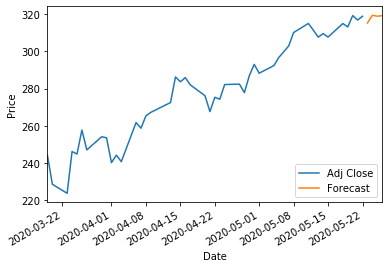

```
Date
2020-05-22           NaN
2020-05-23    315.260838
2020-05-24    319.405347
2020-05-25    318.899776
2020-05-26    319.177271
Name: Forecast, dtype: float64
```

```python
forecast_set = forecast_lg.predict(X_lately)
stock_data['Forecast'] = np.nan

last_date = stock_data.iloc[-1].name
last_unix = last_date
next_unix = last_unix + datetime.timedelta(days=1)

for i in forecast_set:
    next_date = next_unix
    next_unix += datetime.timedelta(days=1)
    stock_data.loc[next_date] = [np.nan for _ in range(len(stock_data.columns)-1)]+[i]

stock_data['Adj Close'].tail(50).plot()
stock_data['Forecast'].tail(50).plot()
plt.legend(loc=4)
plt.xlabel('Date')
plt.ylabel('Price')
plt.show()
stock_data['Forecast'].tail()
```